# Analysis and Data Visualization

In this section, I will be analyzing the **general health** of each racial groups based on the **national total death counts***, *counties total death counts*, *percentage of Covid-19 vaccinated inviduals per racial groups*.

The *national total death counts* was compared between the racial groups, in both the total death counts and the change in death counts over the period if 18 months, from *January 2020 to June 2021*.

The top 10 *counties total death counts* were parsed and cross-reference with online government consensus to create a table that shows the demographic breakdown of each counties. This table is used to observe if racial componnent of each countie have any effect on its total death counts.

The *percentage of Covid-19 vaccinated inviduals per racial groups* was used to compare the level of accessibility of the covid-19 vaccinations among the ethnic groups.

### Library

```python
# Loading in data:
import numpy as np
import pandas as pd
#import feather

# Plotting:
import matplotlib
from plotnine import *
import seaborn as sns
from scipy import stats
from mizani.breaks import date_breaks
from mizani.formatters import date_format
import plotnine as p9
from matplotlib.animation import FuncAnimation
%matplotlib inline
from matplotlib import pyplot as plt
plt.style.use('ggplot')



# Maps:
import matplotlib.cm
from matplotlib.patches import Polygon
from matplotlib.colors import Normalize
import geopandas as gpd
import shapely.geometry as geom
from matplotlib.collections import PatchCollection
import os
import conda
conda_file_dir = conda.__file__
conda_dir = conda_file_dir.split('lib')[0]
proj_lib = os.path.join(os.path.join(conda_dir, 'share'), 'proj')
os.environ["PROJ_LIB"] = proj_lib
from mpl_toolkits.basemap import Basemap
import folium
import plotly.express as px
import plotly.graph_objs as go
from plotly.offline import init_notebook_mode, iplot
init_notebook_mode(connected = True)
import plotly.figure_factory as ff




#Animated Bar Plot
import matplotlib.ticker as ticker
import matplotlib.animation as animation
from IPython.display import HTML

import tabulate
```

### Data

```python
counties = pd.read_csv('Covid_Death_State_Counties_level.csv', index_col=0)
race = pd.read_csv("Death_Counts_Race_Group.csv", index_col=0)
vac = pd.read_csv("Vac_Race.csv", index_col=0)
```

# Research Questions:

1. Is there a noticable disparities in the general health and healthcare accessibility within historically marginalizes groups related to Covid-19?
2. Are there counties in the United States that suffer a disproportionatly higher death rate than other places, and is correlated to the high percentages of maringalize groups within the counties' population?

## 1. Preliminary Exploration

### Covid-19 Death by Racial Groups

```python
def group_by(df,col1,col2):
    return df.groupby(col1 , as_index = False)[col2].sum()
```

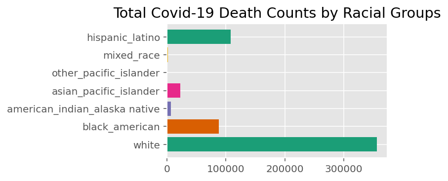

```python
race_state = race.loc[(race['state'] == "United States")]

demo = ['state', 'indicator',
       'white', 'black_american', 'american_indian_alaska native',
       'asian_pacific_islander', 'other_pacific_islander', 'mixed_race',
       'hispanic_latino']
race_tot=race_state[demo]

tot = race_tot.groupby(by='state').sum()
s = tot.loc['United States']
fig, ax = plt.subplots(figsize=(4, 2.5), dpi=144)
colors = plt.cm.Dark2(range(6))
y = s.index
width = s.values
ax.barh(y=y, width=width, color=colors)
plt.title('Total Covid-19 Death Counts by Racial Groups')
;
plt.savefig('covid19_race.png')
```

```python
state = race.loc[(race['state'] != "United States")]
race_tot_state=state[demo]
race_tot_state
tot_state = race_tot_state.groupby(by='state').sum()
tot_state

col= ['white', 'black_american', 'american_indian_alaska native',
       'asian_pacific_islander', 'other_pacific_islander', 'mixed_race',
       'hispanic_latino']

def table(col):
    tab = [["Demographic", "State", "Highest Total Death Counts"]]
    for demo in col:
        li = []
        ind = tot_state[demo].argmax()
        li.append(demo)
        state = tot_state.index[ind]
        li.append(state)
        num = tot_state[demo][ind]
        li.append(num)
        tab.append(li)
    return tab

table = table(col)
table
display(HTML(tabulate.tabulate(table, tablefmt='html')))


#tot_state.index[44]
```

| Demographic | State | Highest Total Death Counts |
| --- | --- | --- |
| white | Texas | 22910.0 |
| black_american | New York City | 7857.0 |
| american_indian_alaska native | Arizona | 1618.0 |
| asian_pacific_islander | California | 8051.0 |
| other_pacific_islander | California | 326.0 |
| mixed_race | California | 387.0 |
| hispanic_latino | California | 30834.0 |

I wanted to know which states holds the highest Covid-19 mortality rates for each of the ethnic groups, surprisingly, the top three most affect ehtnic groups all have their highest total death counts in different states. *With the White, Black, and Hispanic/Latino communities experiencing the highest mortality counts in Texas, New York City, and California respectively*. However, the most interesting finding is that California being the state that has the highest total death counts for four ethnic groups, *Asian Pacific Islander, Other Pacific Islander, Mixed Race, and Hispanic/Latino*.

### Covid-19 Deaths by Counties in the United States

```python
count = counties.sort_values(["dataValue"], ascending=[False])
count
```

|  | id | dataValue | geo | parentGeo | geoId | parentGeoId | geoAbbreviation | parentGeoAbbreviation |
| --- | --- | --- | --- | --- | --- | --- | --- | --- |
| 194 | 3338481 | 24412 | Los Angeles | California | 06037 | 6 | 6037 | CA |
| 592 | 3696293 | 11084 | Cook | Illinois | 17031 | 17 | 17031 | IL |
| 1818 | 4749041 | 10429 | Kings | New York | 36047 | 36 | 36047 | NY |
| 94 | 3251471 | 10120 | Maricopa | Arizona | 04013 | 4 | 4013 | AZ |
| 1835 | 4764995 | 9918 | Queens | New York | 36081 | 36 | 36081 | NY |
| ... | ... | ... | ... | ... | ... | ... | ... | ... |
| 250 | 3388260 | 1 | Dolores | Colorado | 08033 | 8 | 8033 | CO |
| 247 | 3385866 | 1 | Custer | Colorado | 08027 | 8 | 8027 | CO |
| 2681 | 5499421 | 1 | Roberts | Texas | 48393 | 48 | 48393 | TX |
| 2604 | 5432592 | 1 | Irion | Texas | 48235 | 48 | 48235 | TX |
| 1709 | 4651620 | 1 | Thomas | Nebraska | 31171 | 31 | 31171 | NE |

3100 rows × 8 columns

I have sorted this table from descending order based on the number of deaths by Covid-19 to find which counties are affected the most by the pandemic. I can see that counties such as: Los Angeles, Cook, Kings, Maricopa, and Queens are among the few that suffer the highest Covid-19 mortality rate within the United States. The most significant characteristic shared among these counties is that they are all heavily populated urban areas within the United States. However, it does not answer whether the counties' demographic compositions has any affect on the mortality rate of the counties.

### Covid-19 Vaccination

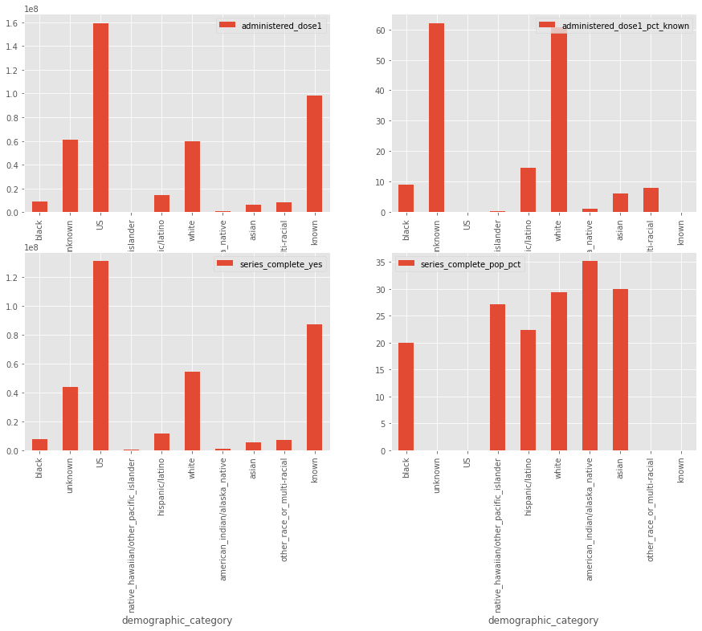

```python
vac_total = vac.loc[vac['date'] == "2021-06-10T00:00:00.000"]
vac_total


fig, axes = plt.subplots(2,2, figsize=(15,10))
vac_total.plot.bar(x='demographic_category', y='administered_dose1', ax=axes[0,0])
vac_total.plot.bar(x='demographic_category', y='administered_dose1_pct_known', ax=axes[0,1])
vac_total.plot.bar(x='demographic_category', y='series_complete_yes', ax=axes[1,0])
vac_total.plot.bar(x='demographic_category', y='series_complete_pop_pct', ax=axes[1,1])
plt.show()
```

## Interactive Graphs

### Death Counts for each Ethnic Group based overtime

```python
race_month = pd.read_csv('Death_Counts_Race_Group.csv', index_col='start_week', parse_dates=['start_week'])

month = [1.0,2.0,3.0,4.0,5.0,6.0,7.0,8.0,9.0,10.0,11.0,12.0]
df = race_month.loc[(race_month['group'] == 'By Month') & (race_month['state'] == "United States") & (race_month["month"].isin(month))]
df = df[['white', 'black_american', 'american_indian_alaska native',
       'asian_pacific_islander', 'other_pacific_islander', 'mixed_race',
       'hispanic_latino']]

s = df.loc['2020-01-01':'2021-05-01']
s = s.reset_index()
s.index = s.index * 5
last_idx = s.index[-1] + 1
df_expanded = s.reindex(range(last_idx))
df_expanded['start_week'] = df_expanded['start_week'].fillna(method='ffill')
df_expanded = df_expanded.set_index('start_week')
df_rank_expanded = df_expanded.rank(axis=1, method='first')
df_expanded = df_expanded.interpolate()
df_rank_expanded = df_rank_expanded.interpolate()
df_rank_expanded


def prepare_data(df, steps=5):
    df = df.reset_index()
    df.index = df.index * steps
    last_idx = df.index[-1] + 1
    df_expanded = df.reindex(range(last_idx))
    df_expanded['start_week'] = df_expanded['start_week'].fillna(method='ffill')
    df_expanded = df_expanded.set_index('start_week')
    df_rank_expanded = df_expanded.rank(axis=1, method='first')
    df_expanded = df_expanded.interpolate()
    df_rank_expanded = df_rank_expanded.interpolate()
    return df_expanded, df_rank_expanded

df_expanded, df_rank_expanded = prepare_data(df)
df_expanded.head()

labels = df_expanded.columns

def nice_axes(ax):
    ax.set_facecolor('.8')
    ax.tick_params(labelsize=8, length=0)
    ax.grid(True, axis='x', color='white')
    ax.set_axisbelow(True)
    [spine.set_visible(False) for spine in ax.spines.values()]

nice_axes(ax)
fig

def init():
    ax.clear()
    nice_axes(ax)
    ax.set_ylim(.2, 6.8)

def update(i):
    for bar in ax.containers:
        bar.remove()
    y = df_rank_expanded.iloc[i]
    width = df_expanded.iloc[i]
    ax.barh(y=y, width=width, color=colors, tick_label=labels)
    date_str = df_expanded.index[i].strftime('%B %-d, %Y')
    ax.set_title(f'COVID-19 Deaths by Racial Groups - {date_str}', fontsize='smaller')

fig = plt.Figure(figsize=(4, 2.5), dpi=144)
ax = fig.add_subplot()
anim = FuncAnimation(fig=fig, func=update, init_func=init, frames=len(df_expanded),
                     interval=100, repeat=False)

anim.save('covid_death.mp4')
html = anim.to_html5_video()
HTML(html)
```

[video not shown]

As observed from the racing bar graph, which reconfirm the finding from the preliminary analysis section, the white community has the highest mortality rate related to Covid-19 since the begining of the pandemic. With the Black and Hispanic communities coming close to surpassing the white community's mortality rate within the months of May to August of 2020.

### Interactive Choropleth Map for Total Death Case from Covid-19

```python
state = race.loc[(race['state'] != "United States")]


#tot_state["total"] = tot_state.sum(axis=1)

code = {'Alabama': 'AL',
        'Alaska': 'AK',
        'Arizona': 'AZ',
        'Arkansas': 'AR',
        'California': 'CA',
        'Colorado': 'CO',
        'Connecticut': 'CT',
        'Delaware': 'DE',
        'District of Columbia': 'DC',
        'Florida': 'FL',
        'Georgia': 'GA',
        'Hawaii': 'HI',
        'Idaho': 'ID',
        'Illinois': 'IL',
        'Indiana': 'IN',
        'Iowa': 'IA',
        'Kansas': 'KS',
        'Kentucky': 'KY',
        'Louisiana': 'LA',
        'Maine': 'ME',
        'Maryland': 'MD',
        'Massachusetts': 'MA',
        'Michigan': 'MI',
        'Minnesota': 'MN',
        'Mississippi': 'MS',
        'Missouri': 'MO',
        'Montana': 'MT',
        'Nebraska': 'NE',
        'Nevada': 'NV',
        'New Hampshire': 'NH',
        'New Jersey': 'NJ',
        'New Mexico': 'NM',
        'New York': 'NY',
        'North Carolina': 'NC',
        'North Dakota': 'ND',
        'Ohio': 'OH',
        'Oklahoma': 'OK',
        'Oregon': 'OR',
        'Pennsylvania': 'PA',
        'Rhode Island': 'RI',
        'South Carolina': 'SC',
        'South Dakota': 'SD',
        'Tennessee': 'TN',
        'Texas': 'TX',
        'Utah': 'UT',
        'Vermont': 'VT',
        'Virginia': 'VA',
        'Washington': 'WA',
        'West Virginia': 'WV',
        'Wisconsin': 'WI',
        'Wyoming': 'WY'}

state['state'] = state['state'].replace(code)
state_df = state[['state',
       'white', 'black_american', 'american_indian_alaska native',
       'asian_pacific_islander', 'other_pacific_islander', 'mixed_race',
       'hispanic_latino']]
state_df = state_df.fillna(0)

state_df["total"] = state_df.sum(axis=1)

df_state_death = state_df[["state", "total"]]
df_state_death
df_tot_state = df_state_death.loc[df_state_death.groupby('state')['total'].idxmax()]
df_tot_state.head()
```

|  | state | total |
| --- | --- | --- |
| 224 | AK | 81.0 |
| 144 | AL | 2376.0 |
| 396 | AR | 1155.0 |
| 312 | AZ | 3970.0 |
| 480 | CA | 19866.0 |

```python
fig = px.choropleth(df_tot_state,
                    locations='state',
                    color='total',
                    color_continuous_scale='spectral_r',
                    hover_name='state',
                    locationmode='USA-states',
                    labels={'total':'Total Death Counts'},
                    scope='usa')
fig.add_scattergeo(
    locations=df_tot_state['state'],
    locationmode='USA-states',
    text=df_tot_state['state'],
    mode='text')

fig.update_layout(
    title={'text':'Covid-19 Death Count by State',
           'xanchor':'center',
           'yanchor':'top',
           'x':0.5})

fig.show()
fig.write_html("Death_by_States.html")
```

[interactive chart not shown]

```python
counties['geoId'] = counties['geoId'].astype(str).apply(lambda x: x.zfill(5))
```

```python
from urllib.request import urlopen
import json
with urlopen('https://raw.githubusercontent.com/plotly/datasets/master/geojson-counties-fips.json') as response:
    countie = json.load(response)
countie
import plotly.express as px
fig = px.choropleth(counties,
    geojson=countie,
    locations='geoId',
    color='dataValue',
    hover_name='geo',
    color_continuous_scale="Viridis",
    range_color=(0, 300),
    scope="usa",
    labels={'dataValue':'Death Counts'}
)

fig.update_layout(
    title={'text':'Covid-19 Death Count by Counties',
           'xanchor':'center',
           'yanchor':'top',
           'x':0.5})
fig.update_layout(margin={"r":0,"t":0,"l":0,"b":0})

fig.show()
fig.write_html("Death_by_Counties.html")
```

[interactive chart not shown]

The two Interactive Choropleth Map for *Covid-19 Death Counts* allows us to observe the area where covid-19 mortality is most concentrated at. It can be noticed that costal regions such as the West and East coasts are places that more commonly shown to have high death counts, particularly counties that are known to be popular tourist destinations.

```python
top_counties = count[0:10]
top_counties.reset_index(inplace=True)

df = pd.DataFrame({"majority_demographic" : ["white", "white", "white", "white", "white", "black", "white", "white", "white", "white"],
                   "demographic_percentage" : ["52.1", "55.4", "36.4", "51.7", "39.7", "35.64", "58.7", "75.87", "52.3", "40.6"]})
df1 = pd.concat([top_counties, df], axis=1)
df1 = df1[["geo", "majority_demographic", "demographic_percentage", "dataValue"]]
headers=["Countie", "majority_demographic", "demographic_percentage", "Death_Count"]
display(HTML(tabulate.tabulate(df1, headers, tablefmt='html')))
```

|  | Countie | majority_demographic | demographic_percentage | Death_Count |
| --- | --- | --- | --- | --- |
| 0 | Los Angeles | white | 52.1 | 24412 |
| 1 | Cook | white | 55.4 | 11084 |
| 2 | Kings | white | 36.4 | 10429 |
| 3 | Maricopa | white | 51.7 | 10120 |
| 4 | Queens | white | 39.7 | 9918 |
| 5 | Bronx | black | 35.64 | 6566 |
| 6 | Harris | white | 58.7 | 6487 |
| 7 | Miami-Dade | white | 75.87 | 6472 |
| 8 | Wayne | white | 52.3 | 5086 |
| 9 | Orange | white | 40.6 | 5073 |

The table describe the demographic of the top ten counties with the highest covid-19 death counts, by listing the majority ethnic group of the counties, the group's overall population percentage within the counties' demographic, and the death counts associated with the counties. Unsurprisingly, the most dominant ethnic group for all the counties, with the exception of Bronx county in New York, is the White community. As discussed before, this could be due to the White community having a bigger overall populations within the United States, making it more likely for individuals within the communities to be infected and die from Covid-19 complications than any other ehtnic groups. However, it should be noted that all of these counties are consider to be metropolitian areas that are heavily populated and trafficked by visitors that have the protential to be Covid-19 hosts. These factor play a crucial role as to why the mortality rates within these counties are significantly higher than other less well-known counties across the United States.

# Conclusion

When looking at the data it is noticable that there are counties within the United States that suffer a higher Covid-19 mortality rate than others, however, these counties tend to be heavily urbanized areas that are tourist destinations making them ideal epicenters for the spread of Covid-19. From the analysis I have done within this report, I can not say that there is a correlation between the Covid-19 death count of a countie and the high percentages of maringalize groups within the counties' population. However, I only looked at 10 counties within this report and might have missed other significant factors that could contribute to the Covid-19 mortality rate of a countie.